# Voting Pattern Analysis

Unsupervised Clustering Algorithm

Navankur Verma - navankurverma@gmail.com

18/03/2020

## Voting Patterns:

### Load data

```r
load("32ndDail_FifthSession_BinaryVotes.Rdata")
parties <- read.csv("TDs_names_parties.csv",header = TRUE, stringsAsFactors = FALSE)

parties$Party <- factor(parties$Party)
str(bin.votes)
```

```
## 'data.frame':    156 obs. of  6 variables:
##  $ Environment       : num  1 1 2 1 1 1 1 1 1 2 ...
##  $ RentFreeze        : num  1 2 1 1 2 1 2 2 2 1 ...
##  $ SocialWelfare     : num  1 2 1 1 2 2 2 2 2 1 ...
##  $ GamingAndLotteries: num  1 2 2 1 1 1 1 2 1 2 ...
##  $ HousingMinister   : num  2 1 1 1 2 2 2 1 1 1 ...
##  $ FirstTimeBuyers   : num  1 2 1 1 2 2 1 2 2 1 ...
```

```r
str(parties)
```

```
## 'data.frame':    156 obs. of  2 variables:
##  $ TD   : chr  "Adams, Gerry." "Aylward, Bobby." "Bailey, Maria." "Barrett, SeÃ¡n." ...
##  $ Party: Factor w/ 9 levels "AAA-PBP","FF",..: 9 2 3 3 1 1 9 2 2 3 ...
```

### 1(a)

Hierarchichal clustering can be applied as initial analysis on the given binary coded data on voting, using various different binary distances.

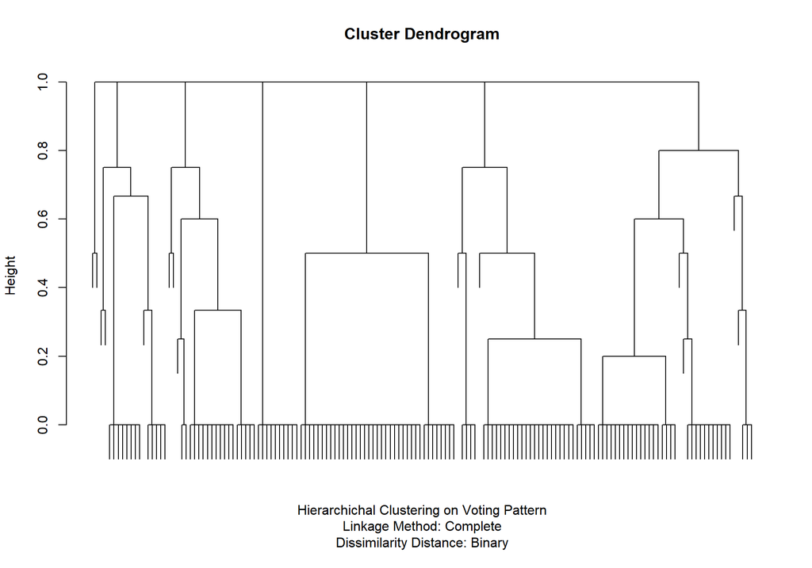

```r
#Encoding  "Yes"(2) into 1s and "No" (1) into 0s
bin.votes[bin.votes == 1] <- 0
bin.votes[bin.votes == 2] <- 1

#Using Binary method for calculating distance:
dbin <- dist(bin.votes, method = "binary")
hcl <- hclust(dbin)
plot(hcl,
     sub = "", labels = FALSE,
     xlab = "Hierarchichal Clustering on Voting Pattern\nLinkage Method: Complete\nDissimilarity Distance: Binary", ylab = "Height")
```

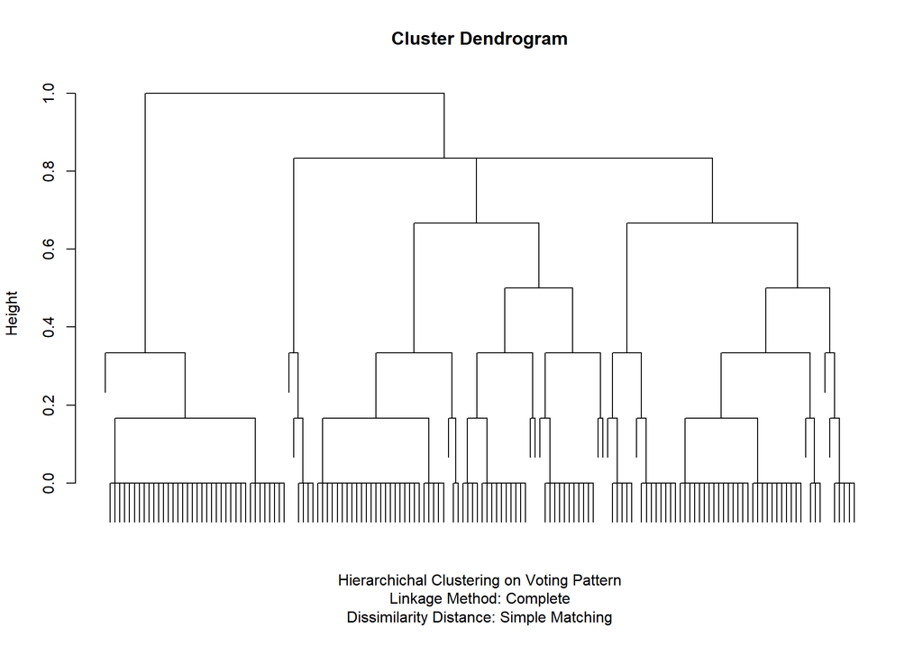

```r
#simple matching distance:
library(nomclust)
dsm <- sm(bin.votes)
hclsm <- hclust(as.dist(dsm))
plot(hclsm,
     sub = "",labels = FALSE,
     xlab = "Hierarchichal Clustering on Voting Pattern\nLinkage Method: Complete\nDissimilarity Distance: Simple Matching", ylab = "Height")
```

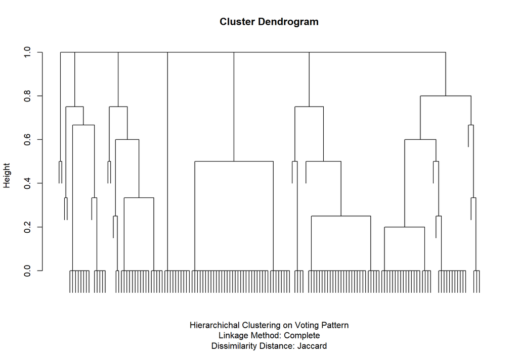

```r
#Using jaccard distance:
library(prabclus)
#input should be matrix with Variables in rows and Observation as columns.
djac <- jaccard(t(as.matrix(bin.votes)))
djac[is.na(djac)] = 0  # Some elements will have NaNs if two of rows are having only zeroes
hcljac <- hclust(as.dist(djac))
plot(hcljac,
     sub = "", labels = FALSE,
     xlab = "Hierarchichal Clustering on Voting Pattern\nLinkage Method: Complete\nDissimilarity Distance: Jaccard", ylab = "Height")
```

```r
h.bin <- cutree(hcl, h = 0.8)
table(h.bin, parties$Party, deparse.level = 2)
```

```
##      parties$Party
## h.bin AAA-PBP FF FG Green I4C Ind Lab SD SF
##     1       5  0  1     1   0   5   3  2 16
##     2       0 21  0     2   1   1   4  0  8
##     3       0  0 36     0   1   0   0  0  0
##     4       0  0  6     0   0   4   0  0  0
##     5       1 13  0     0   1   5   0  1  0
##     6       0  8  6     0   0   2   0  0  0
##     7       0  1  0     0   0   1   0  0  0
```

```r
adjustedRandIndex(h.bin, parties$Party)
```

```
## [1] 0.3640537
```

```r
h.sm <- cutree(hclsm, h = 0.8)
table(h.sm, parties$Party, deparse.level = 2)
```

```
##     parties$Party
## h.sm AAA-PBP FF FG Green I4C Ind Lab SD SF
##    1       6  3  7     3   0  11   4  2 24
##    2       0 40  6     0   0   5   0  1  0
##    3       0  0 36     0   1   1   0  0  0
##    4       0  0  0     0   2   1   3  0  0
```

```r
adjustedRandIndex(h.sm, parties$Party)
```

```
## [1] 0.4262255
```

```r
h.jac <- cutree(hcljac, h = 0.8)
table(h.jac, parties$Party, deparse.level = 2)
```

```
##      parties$Party
## h.jac AAA-PBP FF FG Green I4C Ind Lab SD SF
##     1       5  0  1     1   0   5   3  2 16
##     2       0 21  0     2   1   1   4  0  8
##     3       0  0 36     0   1   0   0  0  0
##     4       0  0  6     0   0   4   0  0  0
##     5       1 13  0     0   1   5   0  1  0
##     6       0  8  6     0   0   2   0  0  0
##     7       0  1  0     0   0   1   0  0  0
```

```r
adjustedRandIndex(h.jac, parties$Party)
```

```
## [1] 0.3640537
```

Based on all the binary and Jaccard distance measurement method, there seems to exist 7 clusters, while with clustering based on simple matching distance suggests 4 clusters. 4 cluster solution would be preferred as the adjusted Rand index is higher when simple matching is used and also because distance calculated using that is proportional to the number of variables where the responses of two observation were different and here we want to highlight the differences between the voting pattern of TDs.

### 1(b)

```r
library(poLCA)

library(doParallel)                 #Using parallel
library(foreach)                    #processing for fast
detectCores()                       #output from
no_cores <- detectCores() - 1       #poLCA for
registerDoParallel(cores=no_cores)  #each iterations

K <- 10 #max number of classes which will be tried to fit:
mod_list <- vector("list", length(K-1)) #each model values will be stored in this list

#again loading dataset afresh
load("32ndDail_FifthSession_BinaryVotes.Rdata")
#data already coded as 1 (Not) and 2 (Yes) which is required for poLCA model:
str(bin.votes)

#formula for poLCA
f <- cbind(Environment, RentFreeze, SocialWelfare,
           GamingAndLotteries, HousingMinister, FirstTimeBuyers)~1

mod_list <- foreach(k=c(2:K), #starting from 2-class to 10-class LCA model
            .packages=c("poLCA",
                        "MASS")) %dopar% {
        poLCA(f,      #foreach assigns poLCA command with different
        bin.votes,    #k-parameter to number of processors available
        nclass=k,     #to run parallelly using dopar operator
        verbose=FALSE,
        maxiter=25000,
        nrep= 100)    #using nrep to reach global maxima
  }
```

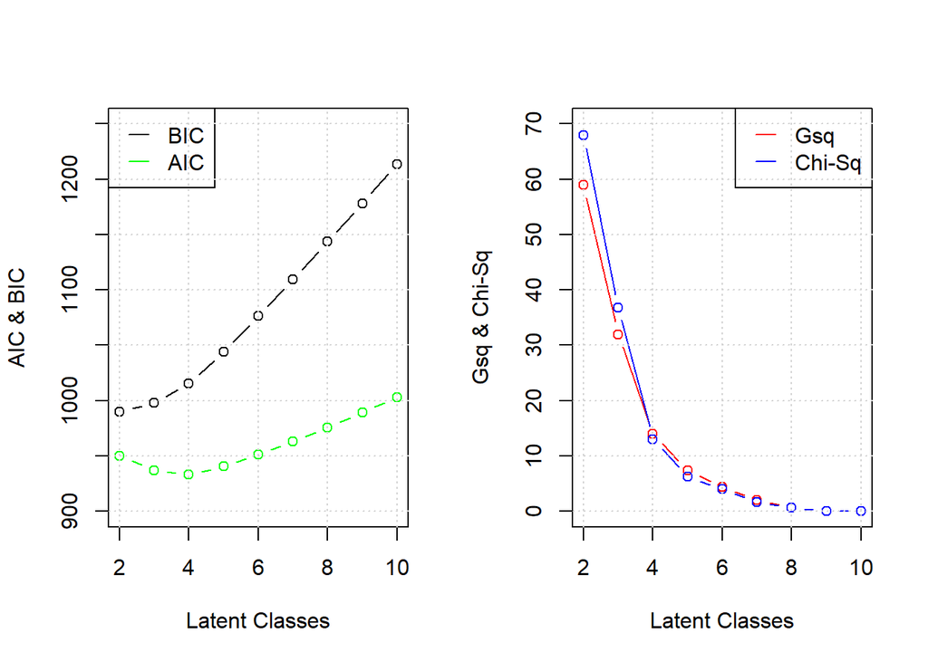

```r
#matrix for storing various measures of goodness of fit for each model
out <- matrix(NA,9,5)
for (i in 1:9) {
  mod <- mod_list[[i]]
  out[i,]<- c(i+1, mod$bic, mod$aic, mod$Gsq, mod$Chisq)
}

par(mfrow = c(1,2))
plot(out[,1],out[,2], type = "b",col = "black", ylim = c(900,1250),
     xlab = "Latent Classes", ylab = "AIC & BIC")
points(out[,1],out[,3], type = "b",col = "green")
legend("topleft", c("BIC","AIC"), col = c("black","green"),
       lty = c(1,1), seg.len = 1, xjust = 0)
grid()

plot(out[,1],out[,4], type = "b",col = "red", ylim = c(0,70),
     xlab = "Latent Classes", ylab = "Gsq & Chi-Sq")
points(out[,1],out[,5], type = "b",col = "blue")
legend("topright", c("Gsq","Chi-Sq"), col = c("red","blue"),
       lty = c(1,1), seg.len = 1, xjust = 1)
grid()
```

```r
par(mfrow = c(1,1))

obsclasses <- mod_list[[8]]$predcell
#Extracting observerd combinations (cross-classification based on input variables) which is returned in all the models and is same in each as the input data is also same.
kable(obsclasses)
```

| Environment | RentFreeze | SocialWelfare | GamingAndLotteries | HousingMinister | FirstTimeBuyers | observed | expected |
| --- | --- | --- | --- | --- | --- | --- | --- |
| 1 | 1 | 1 | 1 | 1 | 1 | 10 | 9.934 |
| 1 | 1 | 1 | 1 | 1 | 2 | 1 | 1.001 |
| 1 | 1 | 1 | 1 | 2 | 1 | 4 | 4.053 |
| 1 | 1 | 1 | 1 | 2 | 2 | 1 | 0.996 |
| 1 | 1 | 1 | 2 | 1 | 1 | 8 | 8.015 |
| 1 | 1 | 2 | 1 | 1 | 1 | 1 | 0.978 |
| 1 | 1 | 2 | 1 | 1 | 2 | 1 | 0.999 |
| 1 | 1 | 2 | 1 | 2 | 1 | 1 | 1.045 |
| 1 | 1 | 2 | 1 | 2 | 2 | 5 | 4.972 |
| 1 | 1 | 2 | 2 | 1 | 1 | 1 | 1.000 |
| 1 | 1 | 2 | 2 | 1 | 2 | 3 | 3.006 |
| 1 | 2 | 1 | 1 | 1 | 1 | 1 | 1.066 |
| 1 | 2 | 1 | 1 | 1 | 2 | 5 | 5.000 |
| 1 | 2 | 1 | 1 | 2 | 1 | 1 | 0.890 |
| 1 | 2 | 1 | 1 | 2 | 2 | 2 | 2.035 |
| 1 | 2 | 1 | 2 | 1 | 1 | 1 | 1.000 |
| 1 | 2 | 1 | 2 | 1 | 2 | 1 | 1.002 |
| 1 | 2 | 1 | 2 | 2 | 2 | 1 | 0.998 |
| 1 | 2 | 2 | 1 | 1 | 1 | 1 | 1.006 |
| 1 | 2 | 2 | 1 | 1 | 2 | 11 | 11.000 |
| 1 | 2 | 2 | 1 | 2 | 1 | 11 | 11.013 |
| 1 | 2 | 2 | 1 | 2 | 2 | 22 | 21.995 |
| 1 | 2 | 2 | 2 | 1 | 1 | 5 | 5.000 |
| 1 | 2 | 2 | 2 | 1 | 2 | 15 | 14.992 |
| 1 | 2 | 2 | 2 | 2 | 1 | 1 | 0.991 |
| 1 | 2 | 2 | 2 | 2 | 2 | 4 | 4.002 |
| 2 | 1 | 1 | 1 | 1 | 1 | 8 | 8.015 |
| 2 | 1 | 1 | 2 | 1 | 1 | 29 | 28.985 |
| 2 | 2 | 1 | 1 | 1 | 1 | 1 | 1.000 |

```r
table(obsclasses$observed < 5)
```

```
##
## FALSE  TRUE
##    11    18
```

18 (out of total 29, almost 62%) cells contain fewer than 5 observations, so chi-square test can not be used here for picking the optimal number of latent classes present in this dataset.

So from AIC and BIC, it seems the model with 4 latent classes gives the minimum AIC eventough BIC is least for 2 but it has not increased alot from 2 to 4.

```r
#choosing model with 4 latent classes which is on index 3 in the mod_list:
mod <- mod_list[[3]]
mod
```

```
## Conditional item response (column) probabilities,
##  by outcome variable, for each class (row)
##
## $Environment
##           Pr(1) Pr(2)
## class 1:  1.000 0.000
## class 2:  1.000 0.000
## class 3:  0.219 0.781
## class 4:  1.000 0.000
##
## $RentFreeze
##            Pr(1)  Pr(2)
## class 1:  0.9410 0.0590
## class 2:  0.1159 0.8841
## class 3:  0.9736 0.0264
## class 4:  0.1555 0.8445
##
## $SocialWelfare
##            Pr(1)  Pr(2)
## class 1:  0.9496 0.0504
## class 2:  0.1683 0.8317
## class 3:  1.0000 0.0000
## class 4:  0.0678 0.9322
##
## $GamingAndLotteries
##            Pr(1)  Pr(2)
## class 1:  1.0000 0.0000
## class 2:  0.4249 0.5751
## class 3:  0.2370 0.7630
## class 4:  1.0000 0.0000
##
## $HousingMinister
##            Pr(1)  Pr(2)
## class 1:  0.6581 0.3419
## class 2:  0.8123 0.1877
## class 3:  1.0000 0.0000
## class 4:  0.0000 1.0000
##
## $FirstTimeBuyers
##            Pr(1)  Pr(2)
```

[output cut: 9 more lines]

```
##  0.109 0.3269 0.2949 0.2692
##
## =========================================================
## Fit for 4 latent classes:
## =========================================================
## number of observations: 156
## number of estimated parameters: 27
## residual degrees of freedom: 36
## maximum log-likelihood: -439.5166
##
## AIC(4): 933.0333
## BIC(4): 1015.379
## G^2(4): 13.95806 (Likelihood ratio/deviance statistic)
## X^2(4): 13.00045 (Chi-square goodness of fit)
##
```

# 1(c)

Comparing the labels predicted from the hierarchical clustering (which used simple matching distances and complete linkage) with poLCA output:

```r
table(h.sm,mod$predclass)
```

```
##
## h.sm  1  2  3  4
##    1 16  2  0 42
##    2  1 43  8  0
##    3  0  0 38  0
##    4  0  6  0  0
```

```r
library(e1071)
classAgreement(table(h.sm,mod$predclass))
```

```
## $diag
## [1] 0.6217949
##
## $kappa
## [1] 0.5068581
##
## $rand
## [1] 0.8462366
##
## $crand
## [1] 0.6307478
```

Adjusted rand index between both the results is 0.6307478 which signifies that there is good amount of agreement between the class labels predicted by both the methods. Visualizing this agreement between both the methods, clusters formed by poLCA method are colored labels at the bottom of each leaf while the clusters formed by hierarchichal method are those which are grouped together after the line at height 0.8 units cuts the dendogram:

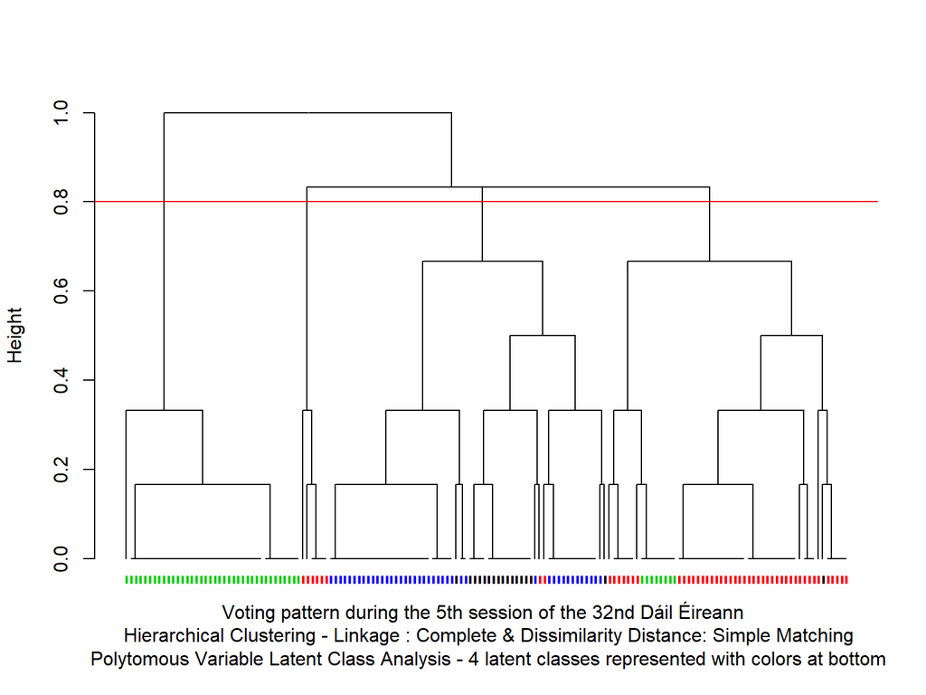

```r
library(dendextend)
dend <- as.dendrogram(hclsm)
labels_colors(dend) <- mod$predclass[order.dendrogram(dend)]
labels(dend) <- rep("-", nrow(bin.votes))
dend <- set(dend, "labels_cex", 1.5)
plot(dend,
xlab = "Voting pattern during the 5th session of the 32nd Dáil Éireann \n Hierarchical Clustering - Linkage : Complete & Dissimilarity Distance: Simple Matching\n Polytomous Variable Latent Class Analysis - 4 latent classes represented with colors at bottom",
ylab = "Height")
abline(h =  0.8, col = "red")
```

### 1(d) Report “Voting Patterns in the 32nd Dáil Éireann”

During the 5th session of the 32nd Dáil Éireann (7 September 2019 - 14 January 2020 inclusive) there were six key debates which underwent the voting in Dáil Éireann by the elected 156 TDs of Ireland representing 9 different parties. Although there were 9 distinct parties, but after studying on the voting patterns of all TDs there seems to be 4 major groups. The study was done on the votes on below six topics:  
1. ‘Housing Minister’ relates to a vote on a motion of no confidence in the current Minister for Housing.  
2. ‘Rent Freeze’ relates to amend the Residential Tenancies Act 2004 (as amended) to provide for a rent freeze for all existing and new tenancies.  
3. ‘Gaming and Lotteries’ relates to various amendments in laws for prohibitions and license permit in respect of Games and lotteries.  
4. ‘Social welfare’ relates to amend and extend the Social Welfare Acts; to amend the National Minimum Wage Act 2000 and the National Training Fund Act 2000; and to provide for related matters.  
5. ‘First Time Buyers’ relates to amend the Planning and Development Act 2000 to provide for a specific percentage of lands in a private development to be limited for purchase by first-time buyers and to provide for related matters.  
6. ‘Environment’ relates to amend the Waste Management Act 1996 to require the Minister to produce a report on the appointment of an independent regulator for the domestic waste management sector, including the regulation of domestic waste charges.

Study was done based on the dataset of the votes of each TD for respective topic encoded categorically, with ‘2’ if TD voted “Yes” and ‘1’ otherwise. It was analyzed using a statistical technique called as polytomous Latent Class Analysis (poLCA), where based on the multiple categorical factors, hidden groups can be declassified. The basic latent class model is a finite mixture model in which the component distributions are assumed to be multi-way cross-classification tables with all variables mutually independent.

The model, in effect, probabilistically groups each observation into a latent class which in turn produces expectations about how that observation will fall in a particular group. The model estimates two parameters for each class and observation, first, class-conditional probability (π) that an observation belonging to a latent class produces certain outcome for a categorical variable, second, prior probabilities (𝑝r) of latent class i.e. representing the unconditional probability that an individual will belong to each class with no further information on their responses on each categorical variable.

As per the analysis done using poLCA, it was found that a model with 4 latent classes gave an optimal solution among other multiple competing models having 2 to 10 classes. Below factors allowed to make such optimal selection:  
1. The two most widely used parsimony measures, the Bayesian information criterion (BIC, Schwartz 1978) and Akaike information criterion(AIC, Akaike 1973), were checked for each competing model and model with 4 classes gave the minimum value of AIC and BIC was also almost equal to the lowest value. These two measures seek to strike a balance between over- and under-fitting the model to the data by penalizing the log-likelihood by a function of the number of parameters being estimated. Because when adding an additional class to a latent class model, the fit will increase but at the risk of fitting of noise too and at the expense of estimating a further large number of parameters.  
2. Since the observed data did not follow the assumptions to be considered for the Chi-Sqaure measure, it was not used as a tool for choosing the model. Assumption required that no fewer than 10-20% of all the combinations that are possible with various levels of categorical variable, should have observed with frequency lesser than 5.  
3. It was not worth to check further the models with more than 10 latent classes because number of residual degrees of freedom gets negative, which is prohibited. 4. The predicted class memberships (based on the model fitted on each observation to calculate it class) and the estimated class memberships (the estimated prior probabilities of each class, 𝑝r) both are very close, which indicates a good fit of the model to the data.

When we further analyze this best suited poLCA model and the 4 classes yielded by it, class 2, 3 and 4 are quite more likely to be observed while class 1 is having low probability. It should be noted that class labels here viz, 1,2,3,4 are merely used for representation and do not hold any other descriptive significance.

The below table shows the extracted conditional probabilities that how much it is likely that an observation of specific class will vote a “Yes” for a categorical variable:

```r
prbs <- mod$probs
nm <- names(prbs)

prb <- data.frame()
for (i in nm) {
  x <- prbs[[i]][,2] #picking only probabilities if event was voted "Yes"
  df <- as.data.frame(round(x,2))
  colnames(df) <- i
  if (ncol(prb) == 0) {
    prb <- df
  }
  else{
    prb <- cbind(prb, df)
  }
}

kable(prb)
```

|  | Environment | RentFreeze | SocialWelfare | GamingAndLotteries | HousingMinister | FirstTimeBuyers |
| --- | --- | --- | --- | --- | --- | --- |
| class 1: | 0.00 | 0.06 | 0.05 | 0.00 | 0.34 | 0.11 |
| class 2: | 0.00 | 0.88 | 0.83 | 0.58 | 0.19 | 0.81 |
| class 3: | 0.78 | 0.03 | 0.00 | 0.76 | 0.00 | 0.00 |
| class 4: | 0.00 | 0.84 | 0.93 | 0.00 | 1.00 | 0.68 |

In the “Environment” topic, model strictly suggest that only class3 voted in favor of it. The topic “HousingMinister” indicates that all observations classified in class4 favor it, while some portion of class1 & class2 also voting in favor of it. While in other topics, mixed reaction can be seen with respect to the predicted classes, with each topic having two classes having their majority in favor of the topic. Visualizing these probabilities:

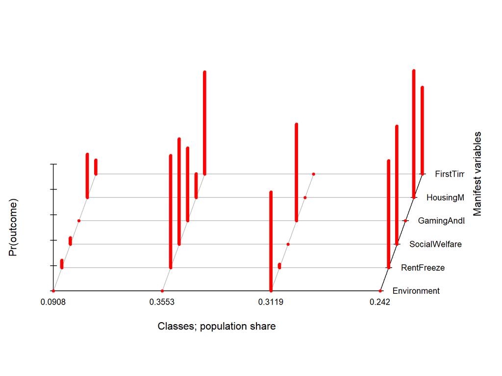

```r
plot(mod)
```

When we incorporate the information of which party a TD represents with the predicted classes from the poLCA model, we get below contingency table:

```r
table(parties$Party, mod$predclass)
```

```
##
##            1  2  3  4
##   AAA-PBP  0  0  0  6
##   FF       2 41  0  0
##   FG       6  0 42  1
##   Green    0  0  0  3
##   I4C      0  2  1  0
##   Ind      7  4  3  4
##   Lab      0  3  0  4
##   SD       0  1  0  2
##   SF       2  0  0 22
```

It can be seen class3 majorly represents FG party, hence we can conclude that FG has supported the topics “Environment” and “Gaming and Lotteries”. In class2, along with majority of TDs of FF party, TDs of I4C, Ind, Lab are also present in that cluster and majority of them have voted in support of topics “First Time Buyers”, “Rent Freeze”, “Social Welfare” & “Gaming and Lotteries”.

```r
table(parties$Party)
```

```
##
## AAA-PBP      FF      FG   Green     I4C     Ind     Lab      SD      SF
##       6      43      49       3       3      18       7       3      24
```

The parties with more than 15 TDs in Dail are FF, FG, SF, Ind. TDs of FF, FG & SF are well clustered in class2, class3 & class4 respectively. It can be seen that TDs of Ind party are not well clustered, as shown below, observing their voting pattern shows that except for topics “Environment” and “Gaming and Lotteries” there was no unity in their votes, which has caused their dispersion in the predicted classes from poLCA.

```r
kable(bin.votes[parties[parties$Party == "Ind",]$TD,])
```

|  | Environment | RentFreeze | SocialWelfare | GamingAndLotteries | HousingMinister | FirstTimeBuyers |
| --- | --- | --- | --- | --- | --- | --- |
| Collins, Michael. | 1 | 2 | 2 | 1 | 2 | 2 |
| Connolly, Catherine. | 1 | 2 | 2 | 2 | 2 | 2 |
| Fitzmaurice, Michael. | 1 | 2 | 2 | 1 | 1 | 2 |
| Grealish, Noel. | 1 | 1 | 1 | 1 | 1 | 1 |
| Halligan, John. | 1 | 1 | 1 | 1 | 1 | 1 |
| Harty, Michael. | 1 | 2 | 2 | 1 | 2 | 2 |
| Healy-Rae, Danny. | 1 | 1 | 1 | 1 | 2 | 1 |
| Healy-Rae, Michael. | 1 | 1 | 1 | 1 | 2 | 1 |
| Healy, Seamus. | 1 | 2 | 2 | 1 | 2 | 2 |
| Lowry, Michael. | 2 | 2 | 1 | 1 | 1 | 1 |
| McGrath, Finian. | 1 | 1 | 1 | 2 | 1 | 1 |
| McGrath, Mattie. | 1 | 1 | 1 | 1 | 2 | 2 |
| Moran, Kevin Boxer. | 1 | 1 | 1 | 1 | 1 | 1 |
| Naughten, Denis. | 1 | 2 | 1 | 1 | 1 | 2 |
| O’Sullivan, Maureen. | 1 | 2 | 1 | 1 | 2 | 2 |
| Pringle, Thomas. | 1 | 2 | 1 | 1 | 1 | 2 |
| Ross, Shane. | 1 | 1 | 1 | 1 | 1 | 1 |
| Zappone, Katherine. | 1 | 1 | 1 | 2 | 1 | 1 |

```r
kable(apply(bin.votes[parties[parties$Party == "Ind",]$TD,], 2, table), row.names = TRUE)
```

|  | Environment | RentFreeze | SocialWelfare | GamingAndLotteries | HousingMinister | FirstTimeBuyers |
| --- | --- | --- | --- | --- | --- | --- |
| 1 | 17 | 9 | 13 | 15 | 10 | 9 |
| 2 | 1 | 9 | 5 | 3 | 8 | 9 |

Based on responses of TDs of AAA-PBP & Green, both the parties fall into class4, showing that they align most with SF party.

```r
classAgreement(table(parties$Party, mod$predclass))
```

```
## $diag
## [1] 0.5512821
##
## $kappa
## [1] 0.4445857
##
## $rand
## [1] 0.8451613
##
## $crand
## [1] 0.5805838
```

Overall, the predicted classes and the known party membership of each TD has good amount of agreement with Rand Index = 84% and Adjusted Rand Index = 58%.